# Synthetic Statistical Analysis Workflow

Zhuoyun Li

November 2026

# 1 Scope and privacy

This report demonstrates an auditable analysis workflow using invented records and generic variable names. Every value, association, figure, and conclusion is synthetic. The material does not reproduce or disclose a confidential dataset, assignment, prompt, organization, or substantive research result.

The analysis asks whether a masked binary exposure is associated with five positive continuous outcomes, whether the estimates are sensitive to alternative modeling choices, whether associations differ across a masked grouping variable, and whether six generic indicators support a one-factor measurement model.

# 2 Reproducible data generation

The dataset is generated by `R/generate_synthetic_data.R` with a fixed seed. Exposure assignment, outcomes, indicators, and missingness are simulated from documented probability models. Regenerating the data produces the same records and outputs.

```r
knitr::kable(qc_summary, digits = 2, caption = "Programmatic quality-control checks")
```

Programmatic quality-control checks

| check | value |
| --- | --- |
| record_count | 840 |
| duplicate_record_ids | 0 |
| invalid_exposure_values | 0 |
| nonpositive_outcome_values | 0 |
| missing_outcome_cells | 264 |
| missing_indicator_cells | 174 |

The checks confirm that the synthetic identifier is unique, the exposure uses the intended coding, and the positive outcomes do not contain invalid nonpositive values. Missing values are retained and summarized rather than silently removed.

# 3 Exploratory analysis

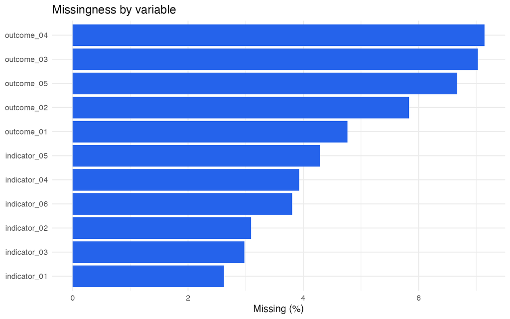

```r
descriptive_display <- descriptive_summary |>
  dplyr::filter(variable %in% c("covariate_01", "covariate_03", "outcome_01", "outcome_04")) |>
  dplyr::select(group, variable, n_observed, missing_n, mean, sd, median, q1, q3)
knitr::kable(descriptive_display, digits = 2, caption = "Selected descriptive summaries")
```

Selected descriptive summaries

| group | variable | n_observed | missing_n | mean | sd | median | q1 | q3 |
| --- | --- | --- | --- | --- | --- | --- | --- | --- |
| Overall | covariate_01 | 840 | 0 | 50.16 | 12.83 | 50.10 | 41.30 | 58.40 |
| Overall | covariate_03 | 840 | 0 | 0.12 | 0.97 | 0.16 | -0.54 | 0.77 |
| Overall | outcome_01 | 800 | 40 | 22.31 | 8.70 | 20.98 | 16.12 | 26.79 |
| Overall | outcome_04 | 780 | 60 | 33.75 | 13.10 | 31.15 | 24.13 | 40.93 |
| Exposure_0 | covariate_01 | 483 | 0 | 48.66 | 12.74 | 48.10 | 40.20 | 57.05 |
| Exposure_0 | covariate_03 | 483 | 0 | 0.15 | 0.99 | 0.20 | -0.52 | 0.83 |
| Exposure_0 | outcome_01 | 461 | 22 | 21.44 | 8.23 | 19.82 | 15.20 | 25.97 |
| Exposure_0 | outcome_04 | 449 | 34 | 32.44 | 12.61 | 29.44 | 23.05 | 39.36 |
| Exposure_1 | covariate_01 | 357 | 0 | 52.19 | 12.68 | 52.30 | 43.40 | 60.30 |
| Exposure_1 | covariate_03 | 357 | 0 | 0.08 | 0.95 | 0.14 | -0.59 | 0.70 |
| Exposure_1 | outcome_01 | 339 | 18 | 23.50 | 9.19 | 22.05 | 16.98 | 28.49 |
| Exposure_1 | outcome_04 | 331 | 26 | 35.52 | 13.56 | 33.00 | 25.62 | 42.87 |

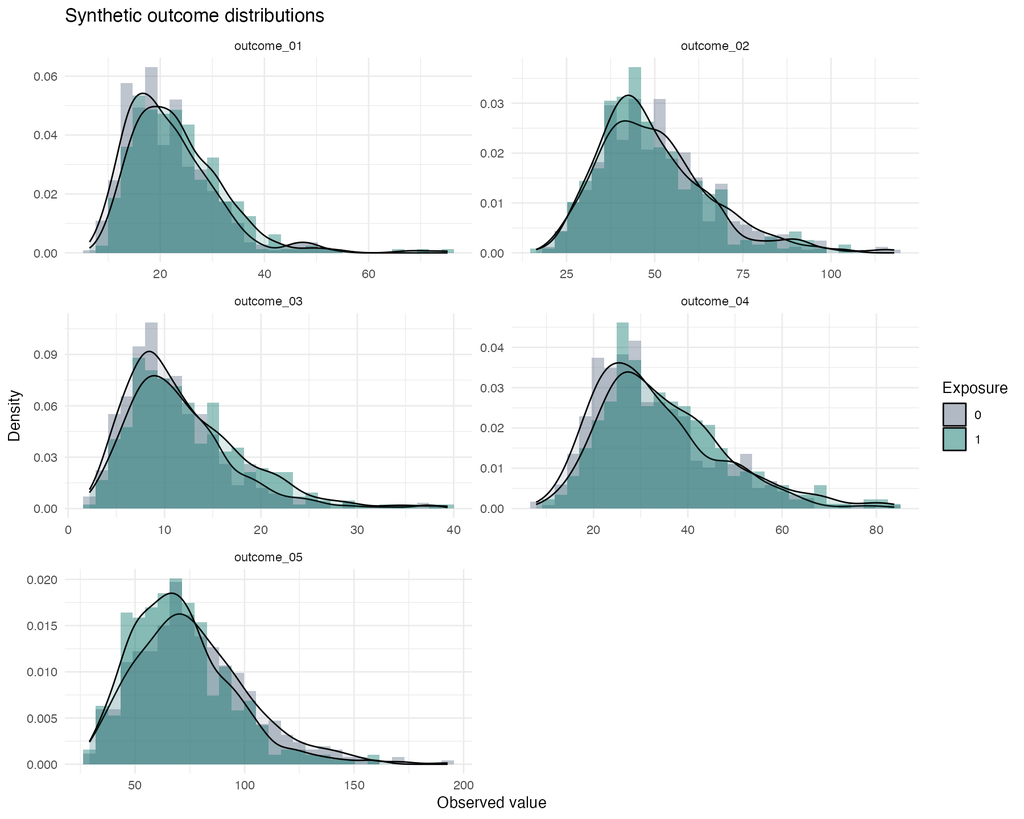

The outcomes are positive and right-skewed by design. That feature motivates modeling their logarithms in the primary analysis and using a Gamma model with a log link as a sensitivity analysis. Extreme observations are visible in the plots, but they are not deleted automatically; their influence is assessed through model diagnostics and alternative specifications.

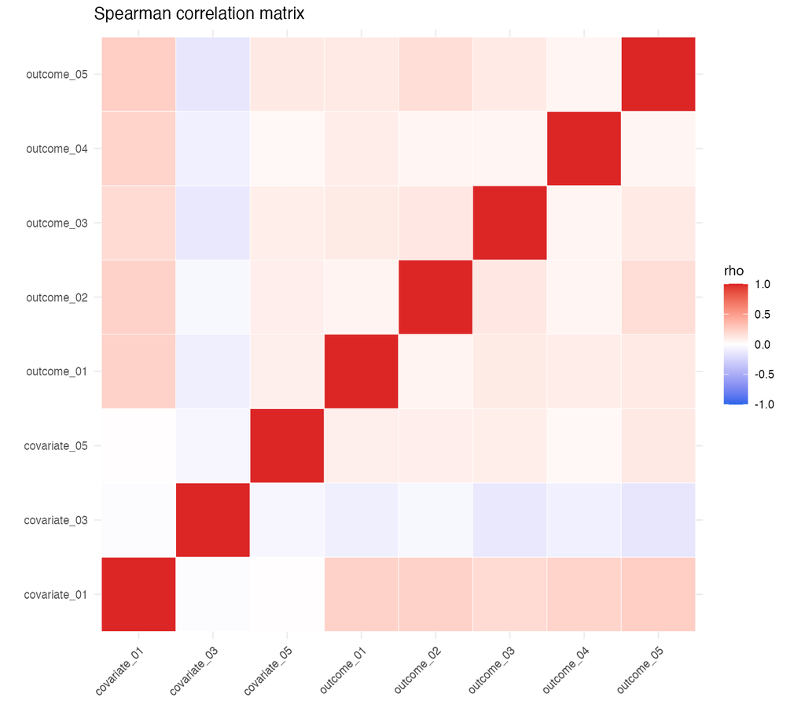

# 4 Primary regression analysis

For each outcome, the primary model regresses the log outcome on `exposure_flag` and the six candidate covariates. HC3 robust standard errors reduce reliance on constant residual variance. Exponentiated exposure coefficients are reported as adjusted percent differences.

```r
primary_display <- primary_results |>
  dplyr::select(outcome, n, percent_difference, lower_95, upper_95, p_value)
knitr::kable(primary_display, digits = 2, caption = "Adjusted exposure estimates")
```

Adjusted exposure estimates

| outcome | n | percent_difference | lower_95 | upper_95 | p_value |
| --- | --- | --- | --- | --- | --- |
| outcome_01 | 800 | 6.25 | 1.08 | 11.68 | 0.02 |
| outcome_02 | 791 | -5.77 | -9.69 | -1.67 | 0.01 |
| outcome_03 | 781 | 9.70 | 2.35 | 17.58 | 0.01 |
| outcome_04 | 780 | 6.40 | 0.89 | 12.20 | 0.02 |
| outcome_05 | 784 | -10.78 | -14.61 | -6.79 | 0.00 |

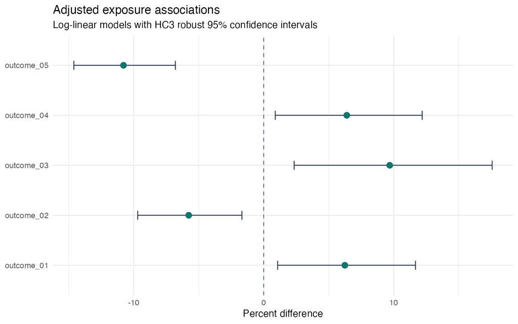

These estimates recover the broad directions built into the synthetic generator while retaining sampling variation and missingness. They demonstrate how to translate log-scale coefficients into an interpretable percent-difference scale. Because the records are synthetic and the design is observational, the estimates are not substantive or causal findings.

# 5 Diagnostics and sensitivity analyses

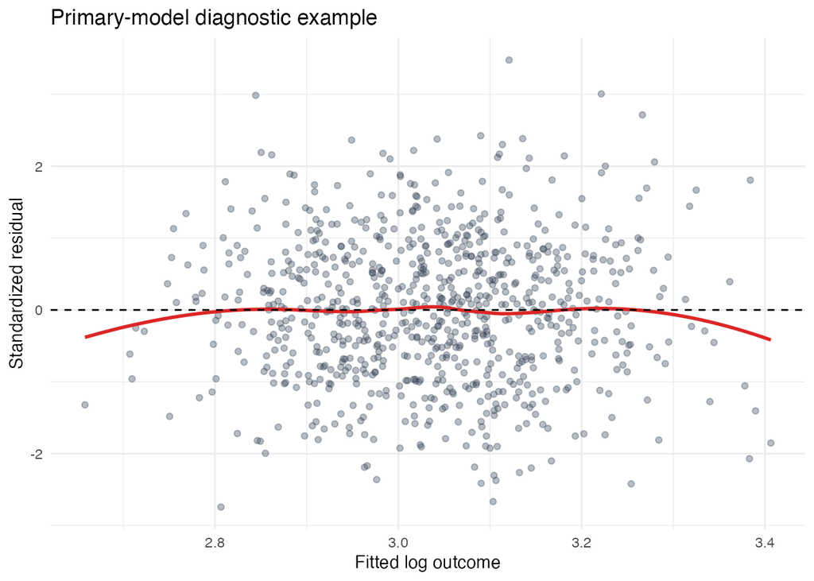

```r
sensitivity_display <- sensitivity_results |>
  dplyr::select(outcome, model, n, percent_difference, lower_95, upper_95, p_value)
knitr::kable(sensitivity_display, digits = 2, caption = "Sensitivity analyses")
```

Sensitivity analyses

|  | outcome | model | n | percent_difference | lower_95 | upper_95 | p_value |
| --- | --- | --- | --- | --- | --- | --- | --- |
| Estimate…1 | outcome_01 | Gamma GLM with log link | 800 | 6.17 | 0.85 | 11.77 | 0.02 |
| Estimate…2 | outcome_01 | Log-linear with nonlinear covariate_01 | 800 | 6.32 | 1.14 | 11.76 | 0.02 |
| Estimate…3 | outcome_02 | Gamma GLM with log link | 791 | -6.00 | -9.94 | -1.89 | 0.00 |
| Estimate…4 | outcome_02 | Log-linear with nonlinear covariate_01 | 791 | -5.73 | -9.67 | -1.62 | 0.01 |
| Estimate…5 | outcome_03 | Gamma GLM with log link | 781 | 10.32 | 2.87 | 18.30 | 0.01 |
| Estimate…6 | outcome_03 | Log-linear with nonlinear covariate_01 | 781 | 9.80 | 2.45 | 17.69 | 0.01 |
| Estimate…7 | outcome_04 | Gamma GLM with log link | 780 | 6.04 | 0.55 | 11.83 | 0.03 |
| Estimate…8 | outcome_04 | Log-linear with nonlinear covariate_01 | 780 | 6.42 | 0.92 | 12.22 | 0.02 |
| Estimate…9 | outcome_05 | Gamma GLM with log link | 784 | -11.19 | -15.09 | -7.11 | 0.00 |
| Estimate…10 | outcome_05 | Log-linear with nonlinear covariate_01 | 784 | -10.78 | -14.60 | -6.79 | 0.00 |

The Gamma models preserve the positive outcome scale, while the spline models relax the assumption that `covariate_01` has a linear relationship with the log outcome. Agreement across models supports numerical stability within this synthetic example; disagreement would be a reason to revisit functional form, influential observations, and the estimand.

# 6 Effect modification

```r
interaction_display <- interaction_results |>
  dplyr::filter(outcome %in% c("outcome_01", "outcome_03", "outcome_05"))
knitr::kable(interaction_display, digits = 2, caption = "Group-specific adjusted exposure estimates")
```

Group-specific adjusted exposure estimates

| outcome | moderator_group | n | percent_difference | lower_95 | upper_95 |
| --- | --- | --- | --- | --- | --- |
| outcome_01 | Group_A | 800 | 9.58 | 1.32 | 18.51 |
| outcome_01 | Group_B | 800 | -0.83 | -8.58 | 7.57 |
| outcome_01 | Group_C | 800 | 14.86 | 4.00 | 26.86 |
| outcome_03 | Group_A | 781 | 9.15 | -2.20 | 21.81 |
| outcome_03 | Group_B | 781 | 6.13 | -4.99 | 18.56 |
| outcome_03 | Group_C | 781 | 16.98 | 1.67 | 34.60 |
| outcome_05 | Group_A | 784 | -7.29 | -13.32 | -0.84 |
| outcome_05 | Group_B | 784 | -12.87 | -19.21 | -6.03 |
| outcome_05 | Group_C | 784 | -11.63 | -19.30 | -3.23 |

Group-specific estimates are calculated as linear contrasts of the exposure main effect and the relevant interaction coefficient. Wide intervals should be interpreted as limited information rather than evidence that groups are equivalent.

# 7 Latent-variable analysis

The two reverse-direction indicators are reoriented before standardization. A one-factor CFA then evaluates whether the six indicators behave as measures of a common generic construct.

```r
knitr::kable(cfa_fit_table, digits = 3, caption = "CFA fit indices")
```

CFA fit indices

| metric | value |
| --- | --- |
| cfi | 0.995 |
| tli | 0.992 |
| rmsea | 0.033 |
| srmr | 0.014 |

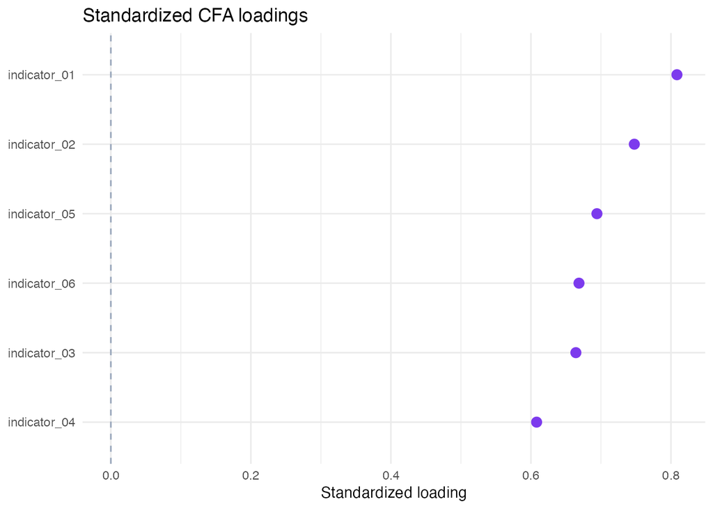

The exploratory SEM adds `outcome_04` as a possible intermediate variable between exposure and the latent construct. Bootstrap intervals summarize uncertainty in the indirect effect.

```r
knitr::kable(sem_paths, digits = 3, caption = "Exploratory SEM path estimates")
```

Exploratory SEM path estimates

| path | estimate | lower_95 | upper_95 | standardized_estimate | p_value |
| --- | --- | --- | --- | --- | --- |
| a | 0.186 | 0.024 | 0.350 | 0.092 | 0.023 |
| b | 0.110 | 0.029 | 0.186 | 0.134 | 0.005 |
| cprime | -0.026 | -0.167 | 0.124 | -0.016 | 0.715 |
| indirect | 0.020 | 0.002 | 0.044 | 0.012 | 0.077 |
| total | -0.005 | -0.157 | 0.141 | -0.003 | 0.942 |

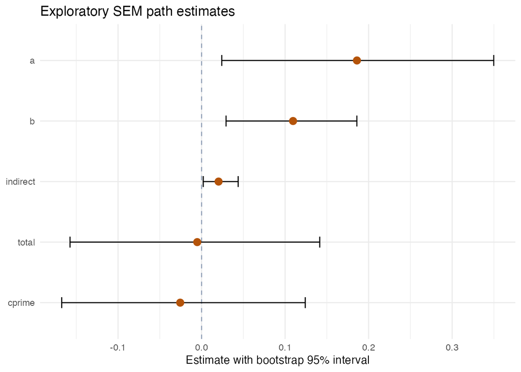

The pathway model is a demonstration of estimation and reporting. Cross-sectional associations, even with a labeled indirect path, do not establish temporal ordering or mediation.

# 8 Limitations

- The data are synthetic and intentionally simplified.
- Missingness is handled differently across analyses: CFA uses full-information maximum likelihood, while regression and SEM examples use available complete records for their required variables.
- The primary models adjust for a fixed set of generic covariates, not a causal graph derived from subject-matter knowledge.
- Multiple outcomes and interaction contrasts are presented for workflow demonstration rather than confirmatory inference.
- The SEM is exploratory and cannot establish a causal mechanism.

# 9 Reproducibility notes

The repository includes the generator, analysis script, dictionary, tables, figures, and this report. A reviewer can trace each displayed result to a scripted output and regenerate the project from a clean R session.